# Data exploration of the immune response of wild mice against parasite infections

Fay

2024-02-01

# Data structure of field and laboratory data sets

## Data originating from yearly field excursions in the House Mouse Hybrid Zone

GitHub repository: https://github.com/derele/Mouse_Eimeria_Field/tree/master

### Infection intensity data

*Eimeria spp.* oocysts counting:

counter: character, Person who counted Feces_g: numeric, amount of feces used in flotation Date_count: date counted N_oocysts_sq1 … sq8: numeric, individual count for each single square on the neubaure chamber (up to 8) mean_neubauer: numeric, mean of the 8 squares PBS_dil_in_mL: numeric, in which volume of PBS whas Ncells: number of neubauer “cells” (squares) counted OPG: oocysts per gram feces (calculated from the above) In some cases only OPG data might be available or rather data would need to be re-formatted to access all the raw values.

*Eimeria spp.* detection qPCR We perform relative qPCR for detection and quantification of Eimeria DNA in intestinal tissue. We amplify a locus in the nuclear genome of the house mouse and a locus in the mitochondrial genome (COI) of Eimeria. We then calculate a “delta” between the two ct values.

delta_ct_ilwe_MminusE: threshold cycle for mouse minus Eimeria in Ileum tissue. Only E. vermiformis is (at low pervalence in Ileum tissue) and we therefore don’t obtain this data-type for all years.

delta_ct_cewe_MminusE: threshold cycle for mouse minus Eimeria in Caecume tissue. E. ferrisi and E. falcifromis are detected here. We should have this (as coprehensively as possible) for every year!

MC.Eimeria: TRUE/FALSE. This was established in 2018 as an improvement over the ‘> -5 delta ct rule’ for identification of Eimeria -positive qPCRs. Melting curves have to show a drastic drop at XX°C to indicate melting of a proper Eimeria COI amplification product. It might be added where possible for per 2018 data post-hoc (if melting curves exist for a review of raw data).

## Data structure - laboratory challenge infections with *Eimeria spp.*

Contains data for challenge (repeated) infections performed between 2017 and 2019. The data product is structure in the following columns:

Mouse_ID: the unique identifier of the mouse experiment: the experiment as numbered in the overview table mouse_strain: the strain (inbred or outbred) of the mouse primary_infection: The Eimeria strain used for the primary infection challenge_infection: The Eimeria strain used for the challenge infection infection_history: The resulting infection history labels: the unique label of the fecal sample at a particular dpi weight: the weight of the mouse at this dpi weight_dpi0: the weight at the day of infection relative_weight: the weight of the mouse at this dpi relative to the weight at dpi0 feces_weight: the weight of the feces collected at this dpi dpi: days post infection at which samples and data in this row were taken infection: the infection (primary or challenge) this row/dpi corresponds to oocyst_sq1, oocyst_sq2, oocyst_sq3, oocyst_sq4: the raw values for squared during oocyst counting dilution: the amount of PBS the feces (with it’s relative weight) was dissolved in OO4sq: the sum of oocysts in the four counting squares OOC: the overall number of oocysts in in the feces (of a particular weight) at this dpi OPG_O: Old way of counting opg (Emanuel ask me) infection_type: what kind of infection are we looking at (challenge or primary, homologous or heterologous immunization). This is differently coded to infection, as here UNI:E88 (first uninfected, then infected with E88) would count as a “primaryE88” infection The next values max_dpi until maximum_weight are calculated for the infection type in which the mice died

max_dpi = maximum dpi that the mouse that the mouse reached for each infection challenge or primary (group_by EH_ID and infection (primary/challenge) to get the value

maximum oocysts for each infection type (group_by EH_ID and infection (primary/challenge) to get the value)

maximum weight loss for each infection type (group_by EH_ID and infection (primary/challenge) to get the value)

death = challenge/primary (in which infection did the mouse die

Eim_MC = Melting curve for eimeria

delta = delta ct value

# Experimental planning - Laboratory infections

## Selected mouse strains

- four wild-derived inbred mouse strains along with their respective F1 hybrids.
- Two of these strains, SCHUNT and STRA, represent M. m. domesticus.
- The strains BUSNA and PWD were derived from M. m. musculus
- Two intersubspecific hybrids (STRAxBUSNA and SCHUNTxPWD) and
- Two intrasubspecific hybrids (SCHUNTxSTRA and PWDxBUSNA).

|  | hybrid_status |
| --- | --- |
| SCHUNT | M. m. domesticus |
| STRA | M. m. domesticus |
| BUSNA | M. m. musculus |
| PWD | M. m. musculus |
| STRA BUSNA | intersubspecific hybrids |
| SCHUNT PWD | intersubspecific hybrids |
| SCHUNT STRA | intrasubspecific hybrids |
| PWD BUSNA | intrasubspecific hybrids |

Numbers of each mouse strain

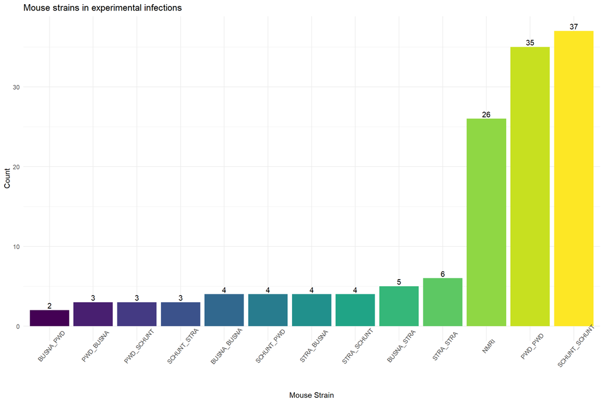

## Selected parasite strains

Infections were initiated by oral administration of 150 sporulated Eimeria oocysts * Up to 16 species of Eimeria have been described from house mice * Overall prevalence in the wild 25.9% * Prevalence of *E. ferrisi* 14 % * Prevalence of *E. falciformis* 4%

As a proxy for health we use the maximum relative weight lost during infection

Maximum weight loss = highest relative weight on any day of the experiment / starting weight

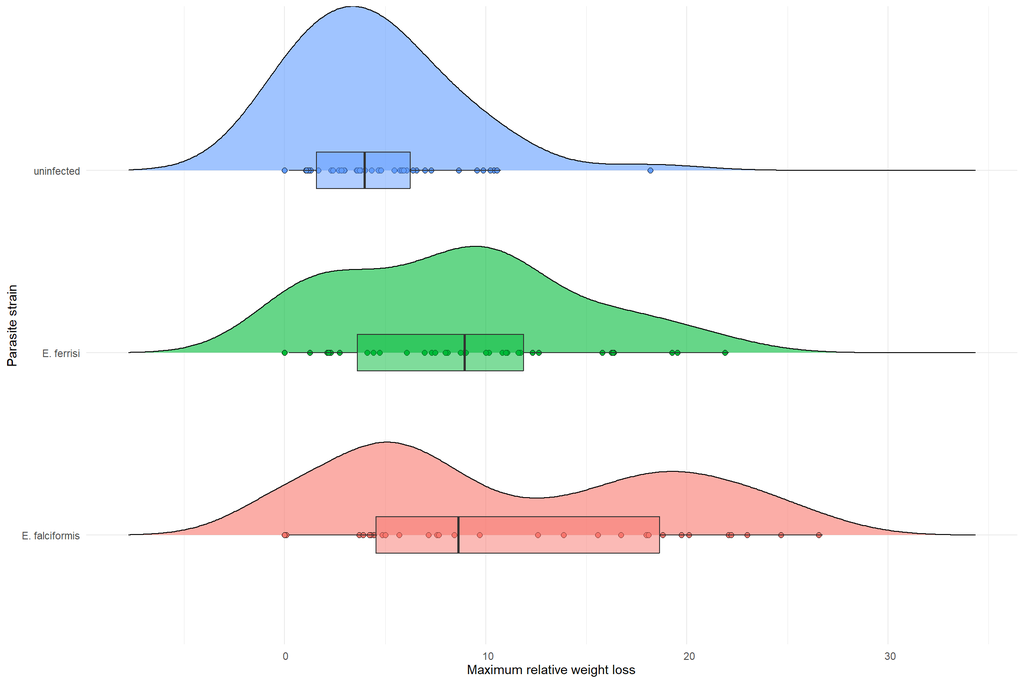

Most of the mice in this experiment, are mice that have been challenged (infected for a second time). This replicates more accurately what happens in the wild. A much higher weight loss is expected in the primary infections.

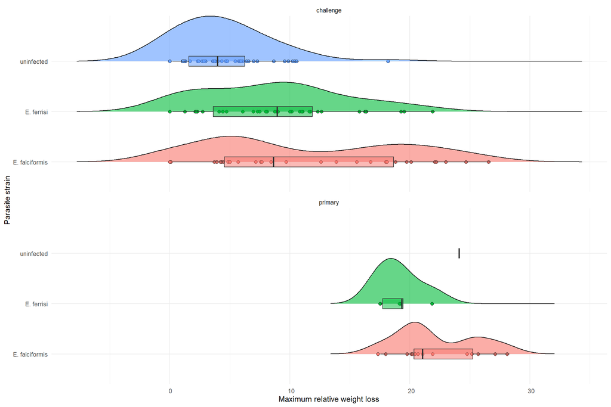

## Weight loss per mouse strain

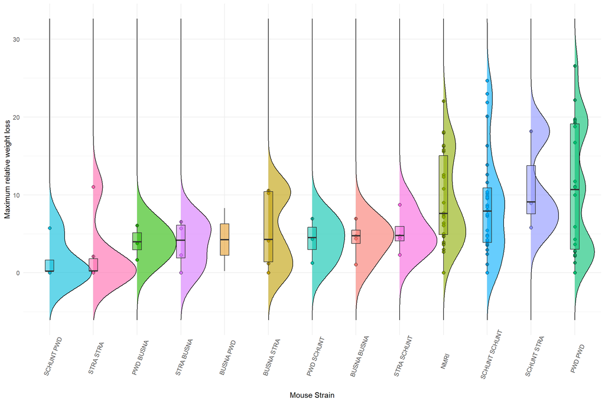

### Weight loss per mouse strain, challenge infections vs primary infections

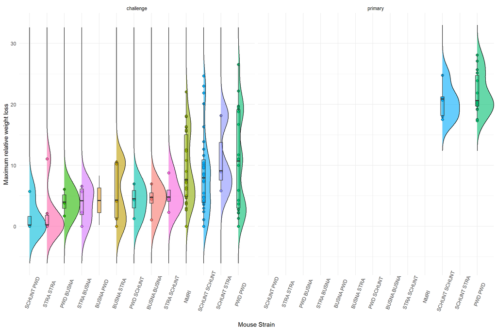

## Preliminary data analysis immune data from laboratory infection experiments

### For how many mice do we have immune data?

```r
length(lab$Mouse_ID)
```

```
## [1] 136
```

### How many mice in primary and how many in challenge infections?

```r
lab %>%
    group_by(infection) %>%
    summarize(n())
```

```
## # A tibble: 2 × 2
##   infection `n()`
##   <chr>     <int>
## 1 challenge   116
## 2 primary      20
```

### How many mice are there in each infection group?

```r
lab %>%
    group_by(infection, current_infection) %>%
    summarize(n())
```

```
## # A tibble: 6 × 3
## # Groups:   infection [2]
##   infection current_infection `n()`
##   <chr>     <chr>             <int>
## 1 challenge E. falciformis       31
## 2 challenge E. ferrisi           39
## 3 challenge uninfected           46
## 4 primary   E. falciformis       14
## 5 primary   E. ferrisi            5
## 6 primary   uninfected            1
```

### For how many mice do we have FACS data?

```
## [1] 80
```

### For how many mice do we have immune gene expression data?

```
## [1] 136
```

### How many mice have immune gene expression AND FACS data?

```r
length(intersect(FACS_M$Mouse_ID, GENE_M$Mouse_ID))
```

```
## [1] 80
```

For the complete FACS Data set, immune gene expression is complete too.

# Field infections - FACS immune cell data

### Number of mice with FACS data

```
## [1] 94
```

### Number of mice with gene expression data

```
## [1] 336
```

### Capture locations of mice with gene expression data

[interactive chart not shown]

### Capture locations of mice with immune cell data

[interactive chart not shown]

## Immune cells

### Laboratory infections - heatmap of immune cells

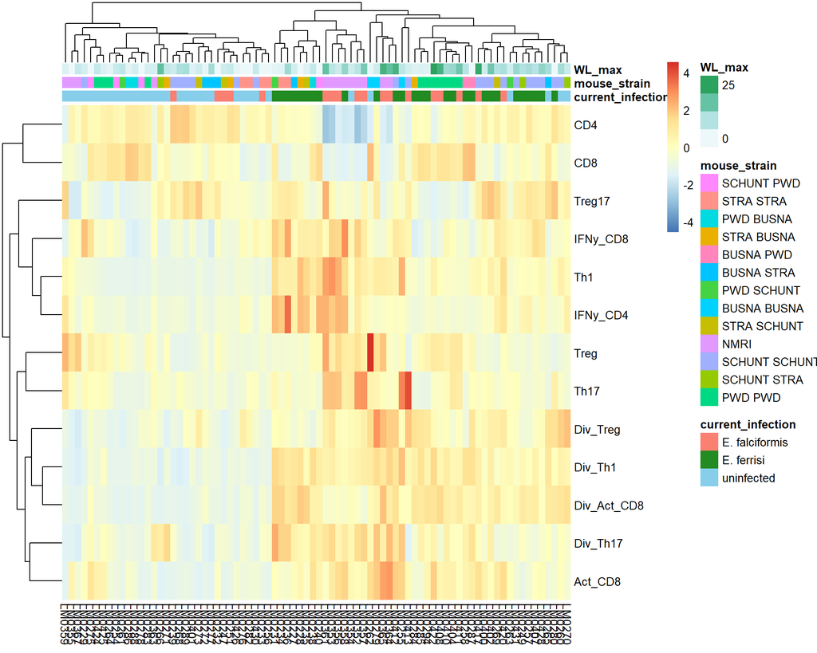

Visual difference between infected and uninfected mice

### Field infections immune cells - heatmap

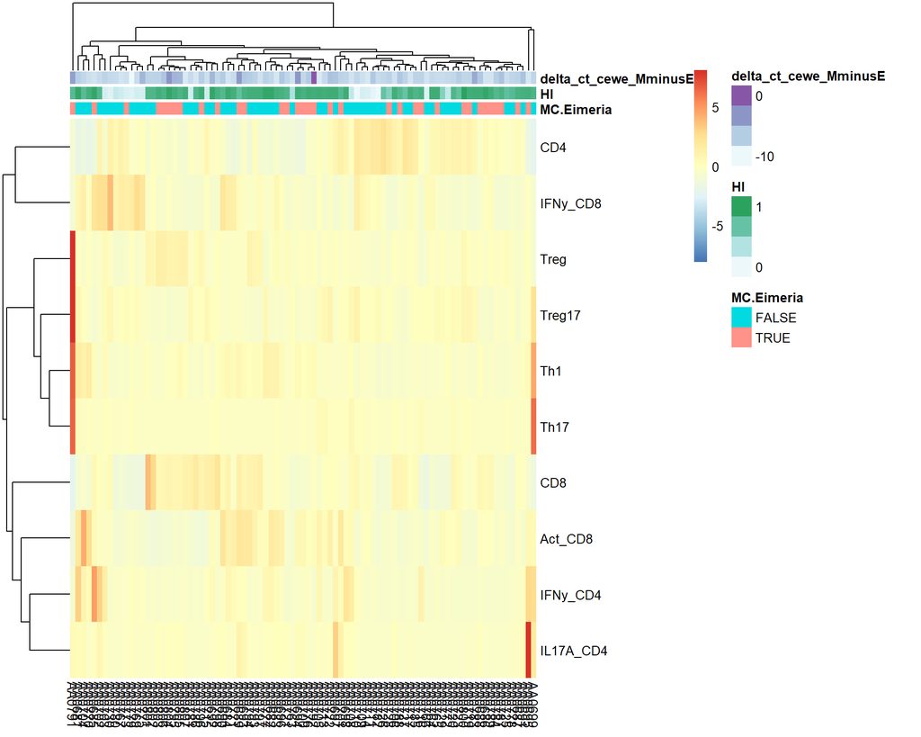

Nothing to gain from this

### Correlation between cells in laboratory challenge infections

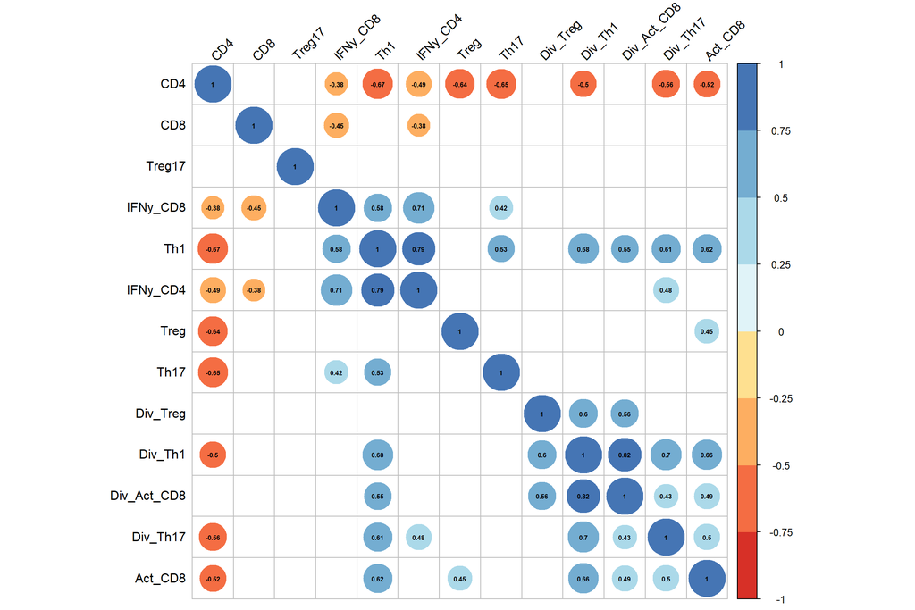

### Correlations between cells in field mice

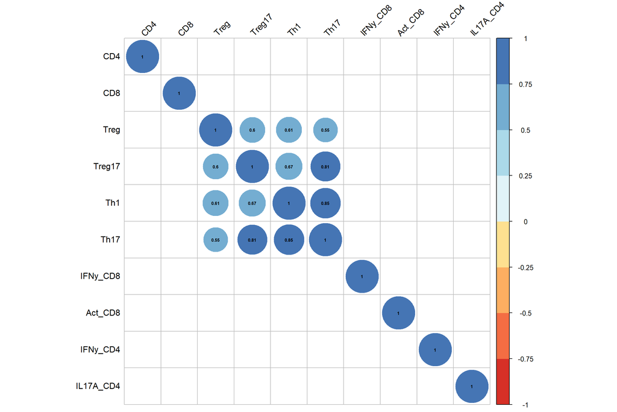

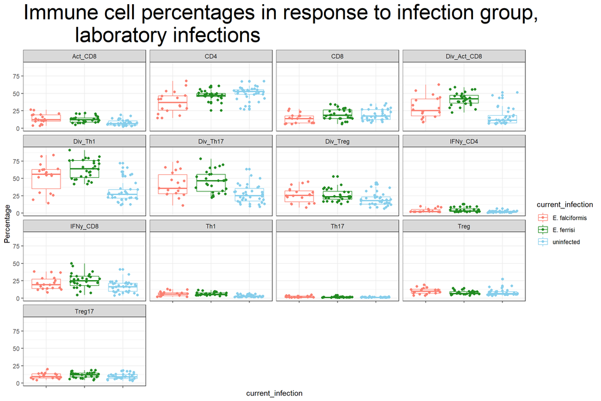

- Missing: completing the data set of genotyping parasites in field samples